# Competitor resilience and Program performance of Alone TV series

Ozgur Ozubek

2023-09-11

##Synopsis

As a part of #TidyTuesday , in this Rpubs, I will try to depict my subjective relation* between the casting resilience of competitors and the rating perforance of the show

- subjective due to some of my claims are yet to be statistically tested.

## Loading data and required libraries

the data is in .csv format and can be directly read from the the following links I just need “episodes”, “survivalists” data sets required libraries are ggplot2 and dplyr

```r
episodes <- readr::read_csv('https://raw.githubusercontent.com/rfordatascience/tidytuesday/master/data/2023/2023-01-24/episodes.csv')

survivalists <- readr::read_csv('https://raw.githubusercontent.com/rfordatascience/tidytuesday/master/data/2023/2023-01-24/survivalists.csv')

library(ggplot2); library(dplyr)
```

## survivalists database

The dataset gives detailed info about each competitor. What we need here is

1. the gender of the competitor (“gender” column)
2. no of days lasted in the competition (“days_lasted” column)

```r
survivalists %>%
  select (season, name, gender, days_lasted)
```

```
## # A tibble: 94 × 4
##    season name             gender days_lasted
##     <dbl> <chr>            <chr>        <dbl>
##  1      1 Alan Kay         Male            56
##  2      1 Sam Larson       Male            55
##  3      1 Mitch Mitchell   Male            43
##  4      1 Lucas Miller     Male            39
##  5      1 Dustin Feher     Male             8
##  6      1 Brant McGee      Male             6
##  7      1 Wayne Russell    Male             4
##  8      1 Joe Robinet      Male             4
##  9      1 Chris Weatherman Male             1
## 10      1 Josh Chavez      Male             0
## # ℹ 84 more rows
```

the boxplot below shows the distribution of the competitors resilience (i.e. days lasted in the season) according to gender

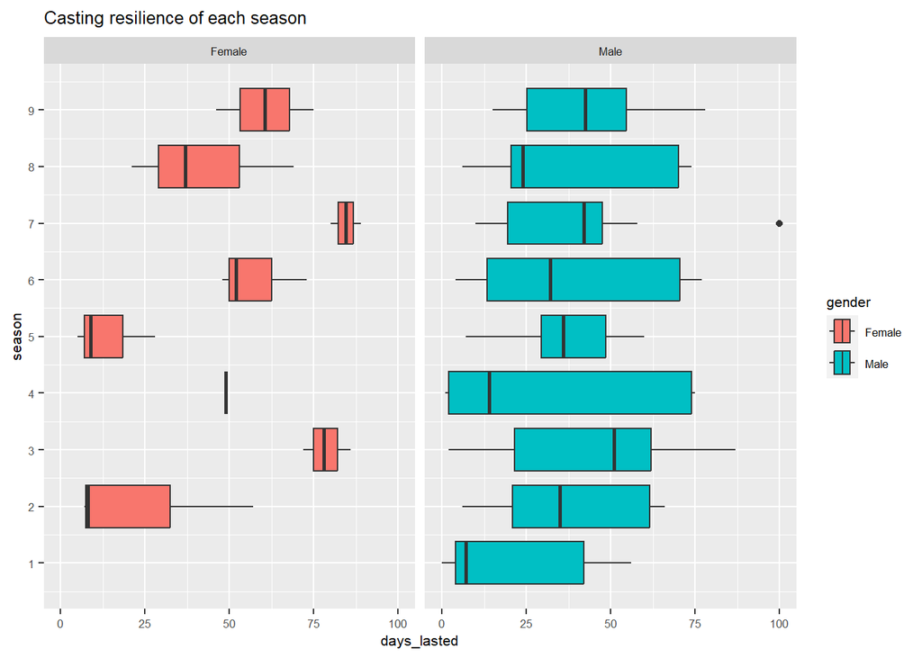

```r
survivalists %>% group_by(season)%>%
 ggplot(aes(y=season , x=days_lasted, fill=gender)) +
        geom_boxplot(aes(group=season)) +facet_wrap(~gender) +
        labs(title="Casting resilience of each season") +
        scale_y_continuous(breaks = seq(min(survivalists$season), max(survivalists$season), by = 1))+
  theme(text = element_text(size = 8))
```

Who says women cant survive alone in the wilderness! Here is what I saw in this graph:

The first season: there were only male competitors with a very poor resilience as majority of the male contestants did not last more than a week or so, meaning in the first of second episodes, majority of the competitors were gone and the show lasted with a handful competitors.  
2nd season: the casting decided to include women in the show this time, yet their selection of women was like their selection of men in the 1st season, as many women competitors got eliminated in the first week. Meanwhile casting did a good job selecting much fitter male competitors as the lasted much more better than the first episode

## Rating performance

Episodes database contains audience performance of all season except 9th season. I just handpicked season, episode and viewer performance figures among others. viewers depict the number of million people who watched the show.

```r
episodes %>% select (season, episode, viewers)
```

```
## # A tibble: 98 × 3
##    season episode viewers
##     <dbl>   <dbl>   <dbl>
##  1      1       1    1.58
##  2      1       2    1.70
##  3      1       3    1.86
##  4      1       4    2.08
##  5      1       5    2.08
##  6      1       6    2.18
##  7      1       7    2.09
##  8      1       8   NA
##  9      1       9    1.80
## 10      1      10    1.94
## # ℹ 88 more rows
```

Below are the rating performance of each season

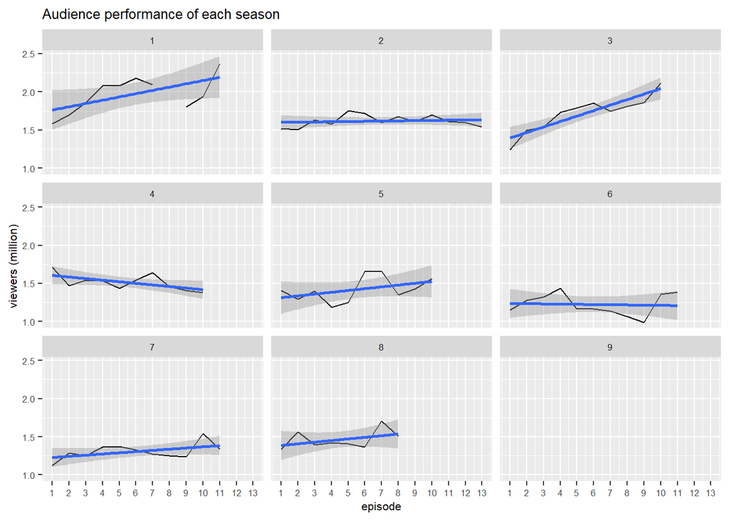

```r
episodes %>%
  ggplot(aes(x=episode, y=viewers)) + geom_line() + facet_wrap(~season) +geom_smooth(method=lm) +
          scale_x_continuous(breaks = seq(1, 13, by = 1))+
          scale_y_continuous(breaks = seq(1, 2.5, by = 0.5))+
          theme(text = element_text(size = 8)) +
          labs(title="Audience performance of each season") + ylab("viewers (million)")
```

If we read these time series with the resilience performance for each season, there are some interesting deductions:

1st season: the first cut is the deepest so just like many shows, the first episode started with huge interest and increased popularity until the finale.

2nd season: neither the inclusion of weak female competitors nor better selection of male competitors did help the rating performance of the show.

3rd season: this is where the casting learned to pick the best ingredients for the show. a handful but super competitive females who last till to the finale and one the best male casting with a best average resilience in show’s history.

4th season: This is where the casting people lost in the woods. just a couple of female competitors and a terrible group of male competitors. with the resilience bar increasing in the first 3 seasons, this was not the audience was expecting from the show. And the ratings, hence the popularity of the show start to erode.

5th season and onwards: from now on the casting people start to increase the quality of the competitors, yet thanks the to blow in the 4th season and the natural aging of TV series, the show failed to raise an average audience above 1.5 million.